# Código para Análisis Metabolómico - PEC1

Jose Pablo Delgado Navarro

2025-03-27

# Introducción

Este documento contiene el código R utilizado para procesar y analizar el dataset ST003564 del Metabolomics Workbench, replicando el enfoque del estudio sobre Pap tests. Se genera un objeto de clase `SummarizedExperiment` integrando los datos y metadatos, y se realizan análisis exploratorios (histograma, PCA y clustering). Además, se exportan los metadatos (colData, rowData y metadata) a archivos de texto para su documentación.

> Para un análisis más detallado de esté informe refierase al archivo **Delgado-Navarro-Jose-Pablo-PEC1**, en el repositorio de la PEC.

# Código para el Preprocesamiento de Datos

## Librerias

```r
# Cargar las librerías necesarias
library(readr)           # Para la lectura de archivos
library(tidyr)           # Para manipulación de datos (separar columnas)
library(ggplot2)         # Para la generación de gráficos
library(ggfortify)       # Para facilitar el trazado del PCA
library(pheatmap)        # Para generar heatmaps (clustering)
library(SummarizedExperiment)  # Para la estructura de datos integrados
```

## Importación

```r
# Leer los archivos de resultados de ionización positiva y negativa
ST003564_AN005855_Results <- read.table("ST003564_AN005855_Results.txt", header = TRUE, sep = "\t")
ST003564_AN005856_Results <- read.table("ST003564_AN005856_Results.txt", header = TRUE, sep = "\t")

# Agregar el modo de ionización a cada conjunto de datos
ST003564_AN005855_Results$IonMode <- "Positive"
ST003564_AN005856_Results$IonMode <- "Negative"

# Separar la columna 'mz_rt' en dos columnas: 'mz' (masa/carga) y 'rt' (tiempo de retención)
ST003564_AN005855_Results <- ST003564_AN005855_Results %>%
  separate(col = mz_rt, into = c("mz", "rt"), sep = "_", convert = TRUE)
ST003564_AN005856_Results <- ST003564_AN005856_Results %>%
  separate(col = mz_rt, into = c("mz", "rt"), sep = "_", convert = TRUE)
```

## Creación de la Matriz de Datos y Metadatos

```r
# Crear matrices de intensidades (excluyendo las columnas 'mz', 'rt' e 'IonMode')
matrizDatos_pos <- as.matrix(ST003564_AN005855_Results[, !(names(ST003564_AN005855_Results) %in% c("mz", "rt", "IonMode"))])
matrizDatos_neg <- as.matrix(ST003564_AN005856_Results[, !(names(ST003564_AN005856_Results) %in% c("mz", "rt", "IonMode"))])

# Combinar ambas matrices en una sola matriz de intensidades
matrizDatos <- rbind(matrizDatos_pos, matrizDatos_neg)

# Crear colData: metadatos de las muestras. Se asume que los nombres de las columnas son los identificadores de las muestras.
muestras <- colnames(matrizDatos)
tipoMuestra <- ifelse(grepl("blank", muestras, ignore.case = TRUE), "Blanco",
                      ifelse(grepl("QC", muestras, ignore.case = TRUE), "Control de Calidad", "Muestra"))
colData <- data.frame(SampleName = muestras, SampleType = tipoMuestra, row.names = muestras)

# Crear rowData: metadatos de las características (metabolitos)
rowData <- data.frame(
  mz = c(ST003564_AN005855_Results$mz, ST003564_AN005856_Results$mz),
  rt = c(ST003564_AN005855_Results$rt, ST003564_AN005856_Results$rt),
  IonMode = c(rep("Positive", nrow(ST003564_AN005855_Results)), rep("Negative", nrow(ST003564_AN005856_Results))),
  row.names = rownames(matrizDatos)
)
```

## Creación del Objeto SummarizedExperiment y Asignación de Metadata

```r
# Crear el objeto SummarizedExperiment
PEC1 <- SummarizedExperiment(
  assays = list(counts = matrizDatos),
  colData = colData,
  rowData = rowData
)

# Asignar metadata general al objeto, que describe el dataset y el proceso de obtención
metadata(PEC1) <- list(
  dataset_name = "ST003564 - Metabolomic analysis of Pap tests",
  source = "https://www.metabolomicsworkbench.org/data/DRCCMetadata.php?Mode=Study&StudyID=ST003564",
  description = "Análisis metabolómico de muestras de Pap tests de mujeres mayores de 50 años, realizado mediante UHPLC-MS.",
  study_reference = "Sah et al., Metabolites 2024, 14, 600. https://doi.org/10.3390/metabo14110600",
  processing_date = Sys.Date(),
  ion_modes = c("Positive", "Negative"),
  sample_count = 29,
  analysis_software = "UHPLC-MS",
  comments = "Datos descargados y procesados en R para estructuración en SummarizedExperiment."
)
```

## Exportación de Metadatos a Archivos de Texto

```r
# Exportar colData a un archivo .txt
write.table(as.data.frame(colData(PEC1)), file = "colData.txt", sep = "\t", quote = FALSE, row.names = TRUE)

# Exportar rowData a un archivo .txt
write.table(as.data.frame(rowData(PEC1)), file = "rowData.txt", sep = "\t", quote = FALSE, row.names = TRUE)

# Exportar metadata a un archivo .txt
# Se convierte la lista a data.frame de forma transpuesta para una mejor visualización
metadata_df <- data.frame(t(unlist(metadata(PEC1))))
write.table(metadata_df, file = "metadata.txt", sep = "\t", quote = FALSE, row.names = TRUE)
```

## Descripción de Metadatos

Esta sección describe los metadatos del conjunto de datos utilizado en el análisis metabolómico de Pap tests.

## 1. colData.txt

Contiene información sobre las muestras, incluyendo:  
- **SampleName:** Identificador de la muestra.  
- **SampleType:** Tipo de muestra (Muestra, Blanco, QC).

## 2. rowData.txt

Describe las características de los metabolitos detectados:  
- **mz:** Relación masa/carga.  
- **rt:** Tiempo de retención en la columna UHPLC.  
- **IonMode:** Modo de ionización (Positivo/Negativo).

## 3. metadata.txt

Contiene una descripción general del dataset, incluyendo su origen y procesamiento.

## Exportar el objeto SummarizedExperiment (PEC1)

```r
save(PEC1, file = "Delgado-Navarro-Jose-PabloPEC1.rda")
```

# Código para el Análisis Exploratorio

## Distribución de Intensidades

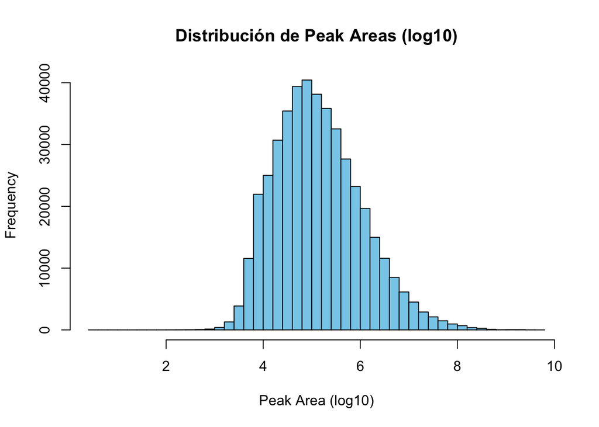

```r
# Histograma de las intensidades (transformadas a escala log10)
hist(log10(assay(PEC1) + 1), breaks = 50,
     col = "skyblue",
     main = "Distribución de Peak Areas (log10)",
     xlab = "Peak Area (log10)")
```